# Sales Analysis

Mo’men Mohamed

12/31/2019

# Sales Review For 2018-2019

## including Compariaons between the Potential Accounts

- The First thing to pay attention to is to compare between the two years in **Total sales Value** as following:

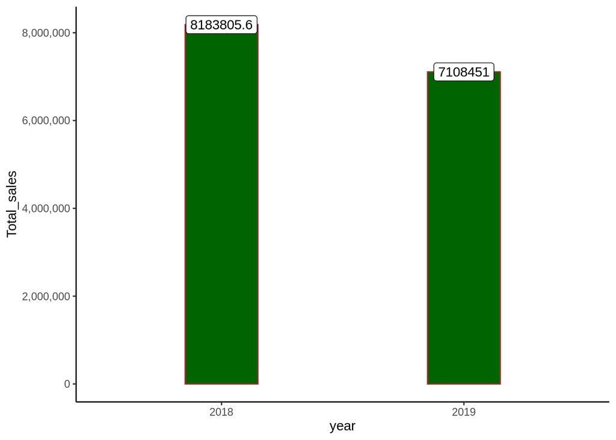

As we See there are like *1 million and 100 thousands* difference between two years , so we need to break the sales down do analyse the gap and know where is the problem!

So, lets see each sector in the two years :

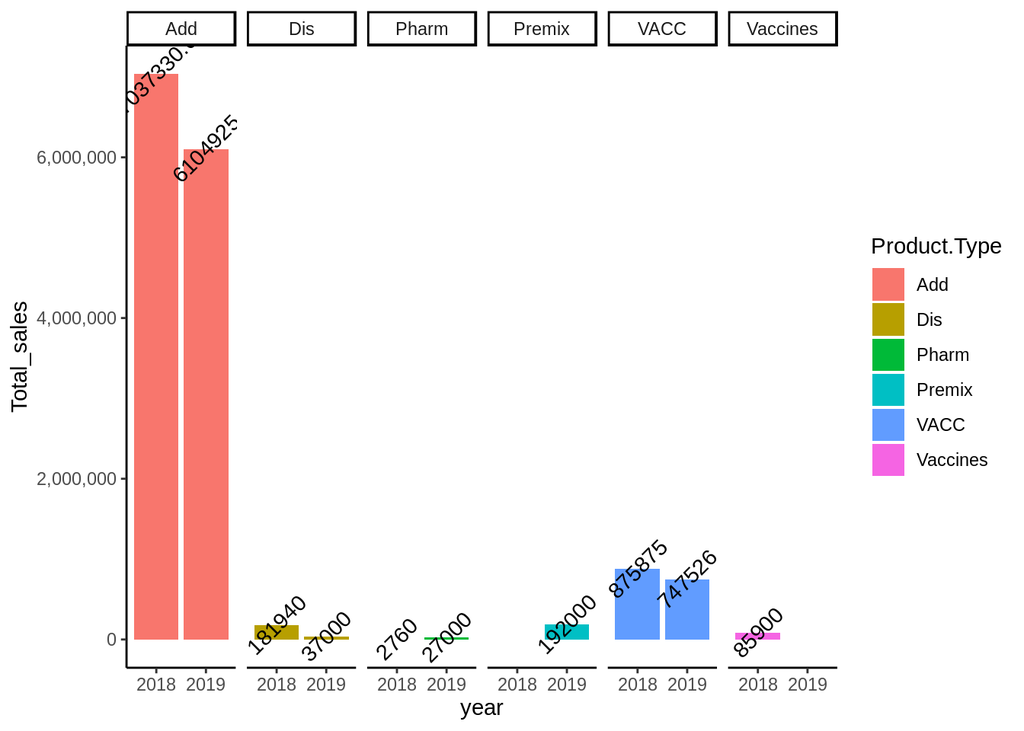

As we see in the previous chart , the gap shrinked from **1100000 EGP** to *900000 EGP*.

we need to know the the precise factor which dropped the sales like that , and also know the area of growth if it exists!

To know that lets First see the Accounts arranged in term of Total sales and see the relative importance of every one in *2019* !

| Customer | Sales |
| --- | --- |
| Dina | 1672500 |
| Copenhagen | 1184000 |
| Delta Misr | 1030000 |
| Enma’a | 894350 |
| Reta Keriasy | 477700 |
| Al Safa ( Al Maikana ) | 400000 |
| Al- Pramos | 276750 |
| Gaber | 153750 |
| Al Nakheil | 144000 |
| Danone | 140000 |
| Al Orouba | 94500 |
| Marimena | 82500 |
| Anba Beshoy | 77728 |
| Al Andalus | 69375 |
| Milkyes | 56100 |
| Madona Al Nehesy | 55000 |
| Ahmed Al Sheikh | 46000 |
| Farm Stars | 40000 |
| Al Sayad | 38808 |
| Goda | 33540 |
| Hassan Hashem | 30000 |
| Alex Land | 18000 |
| The Farm | 16500 |
| Izdehar | 15750 |
| Rashad Fathalla | 15750 |
| Hassan Hefnawy | 15350 |
| Al - Alamia | 8000 |
| Al Safa | 7500 |
| Al Zomor | 7500 |
| Mohamed Ibrahim | 6000 |
| Al Ateba’a | 1500 |

**NOW** im going to throw the spot light on each singl Account of the most Potential one.

The aim is :

- To see the *drop* in sales **Product by Account**
- To see the *growth* also **Product by Account**

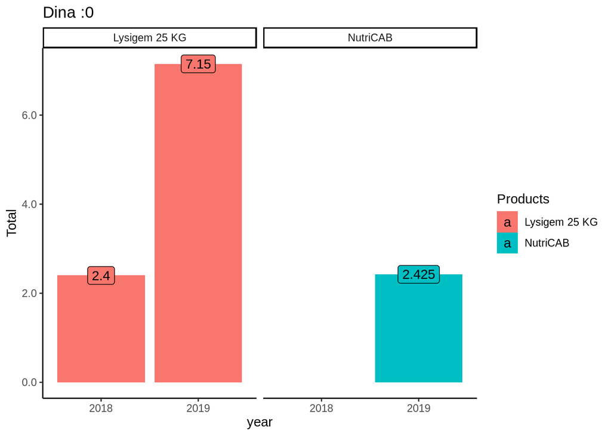

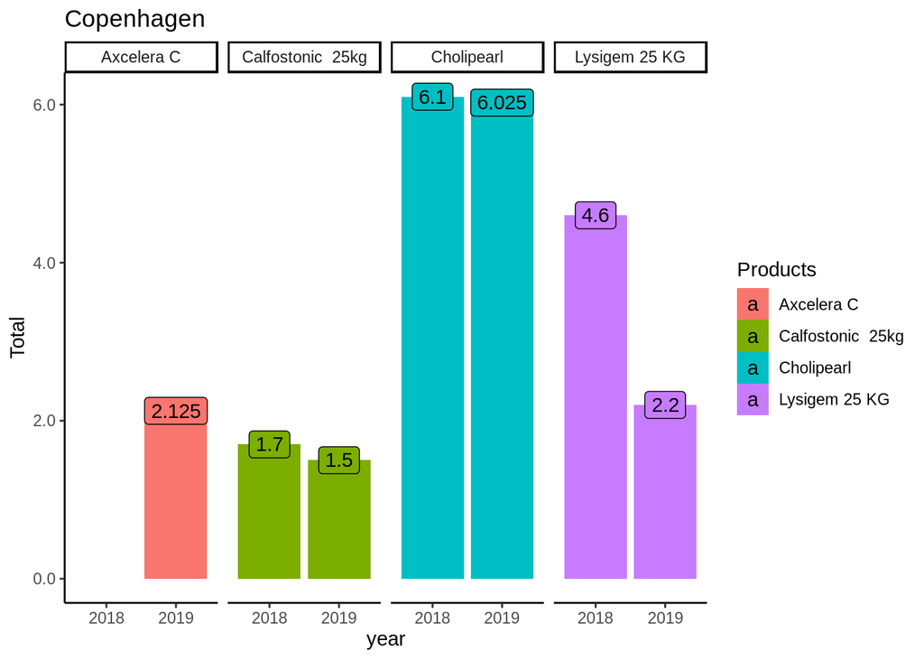

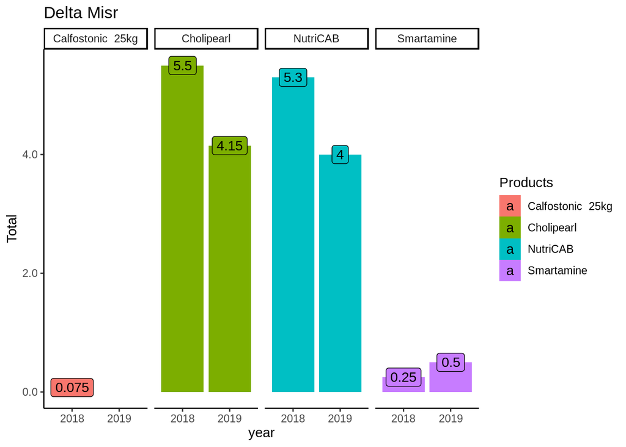

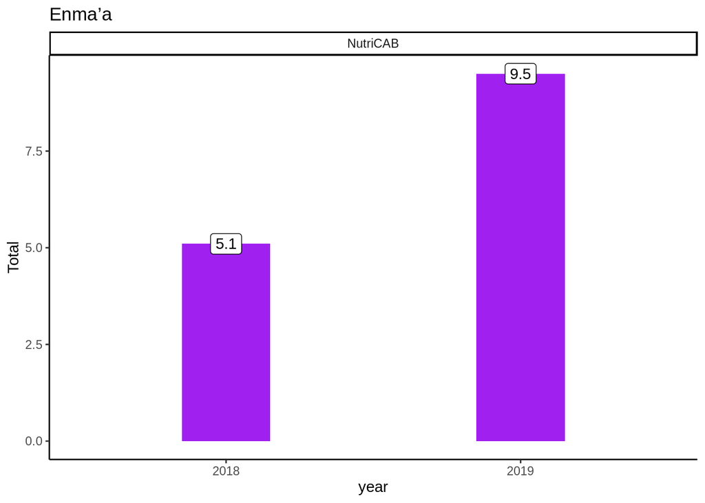

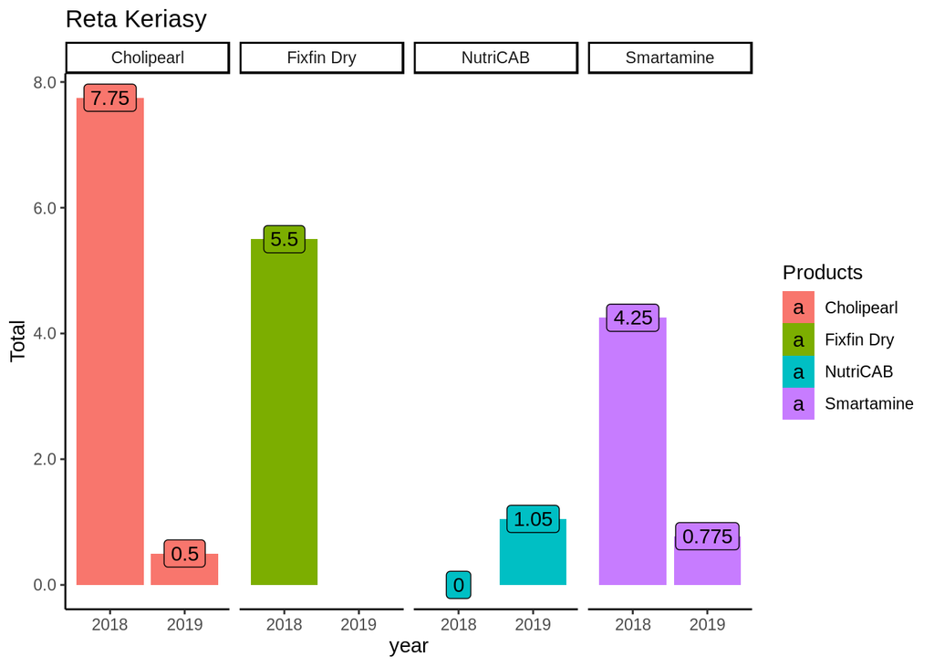

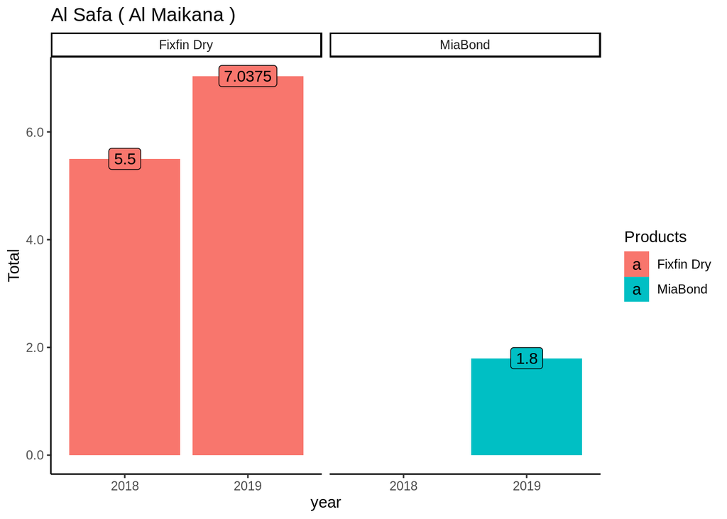

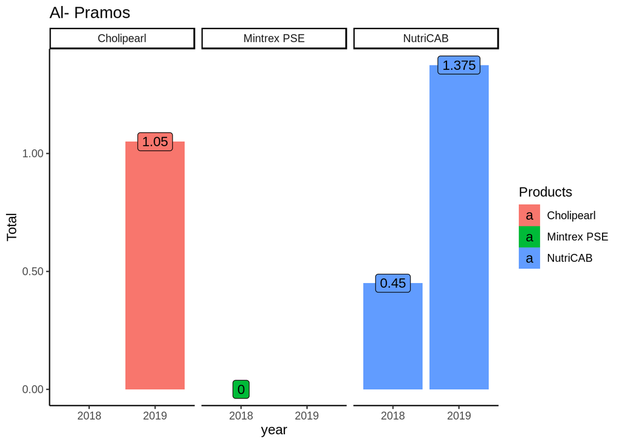

Great, we saw the dropped areas and growth ones in the most potential Farms But To be Honest , There are **other** accounts which holds a great potentiality in the market But we still lack the ability to penetrate it .

in the next table I present all the Farms in the area with the following informations :

- **Account Name**
- **Products In use**
- **Opportunities**
- **Consultant**

| ACCOUNT | POTENIALITY | CONSULT | Smartamine | Lysigem | Cholipearl | Fixfin.Dry | Nutri.CAB | Calfostonic.25Kg | Axcellera.C | PSE | Cr | Mia.Bond | Mia.Bond.360 | Prot.N |
| --- | --- | --- | --- | --- | --- | --- | --- | --- | --- | --- | --- | --- | --- | --- |
| 6 Oct Farm | ***** | Military |  |  |  | % |  | % |  |  |  | % |  |  |
| Copenhagen | ***** | Abd el nasser |  | # | # | % |  | # |  | % |  | % | % | % |
| Danone | ***** | Amr Zeiada |  |  | % |  | % |  | % | % |  |  | % | % |
| Delta Misr | ***** | Deiaa |  |  | # |  | % |  |  | % | % | % |  | % |
| Dina | ***** | Tarek Attia |  | # |  |  | # |  |  |  |  |  |  | % |
| Enma’a | ***** | None – Hegazy |  |  |  |  | # |  |  |  |  |  |  |  |
| Lamar | ***** | Karem |  |  |  |  |  |  |  |  |  |  |  |  |
| Milkeys | ***** | Hany Kamel |  |  |  |  |  |  |  |  |  |  |  |  |
| Rita Keriazy | ***** | Hegazy |  |  | % |  | # |  |  | % |  |  |  |  |
| Safwat Mo’awad | ***** | Hegazy |  |  | % |  | % |  |  |  |  |  |  |  |
| Al Bashayer / Al Hesn | **** | Hegazy |  |  |  | % |  | % |  |  |  | % |  |  |
| Al Ferdaws | **** | Hegazy |  |  |  | % |  | % |  |  |  | % |  |  |
| HyperOne | **** | None |  |  |  | % |  | % |  |  |  | % |  |  |
| Al Gohary | *** | abd al raouf |  |  |  |  |  |  |  |  |  |  |  |  |
| Al Mabrouk | *** | - |  |  |  |  |  |  |  |  |  |  |  |  |
| Al Na’em | *** | Hegazy |  |  |  |  |  |  |  |  |  |  |  |  |
| Al- Safa ( Al Maikana ) | *** | Eng Alaa |  |  |  |  |  | % |  |  |  | % |  |  |
| Al-Safa | *** | Hegazy |  |  |  |  |  |  |  |  |  | % | % | % |
| Al-santa | *** | Hegazy |  |  |  |  |  |  |  |  |  | % |  |  |
| Delta Misr G | *** | Hazem |  |  | % |  | % |  |  | % |  | % | % |  |
| Marimena | *** | None |  |  | # |  |  |  |  |  |  |  |  |  |
| Pramos | *** | Mohamed Samy |  |  | # |  | # |  |  |  |  |  |  |  |
| Rashad Fathallah | *** | Hegazy |  |  |  |  |  |  |  |  |  |  |  |  |
| Teriak | *** | Hegazy |  |  | % |  | % |  |  | % |  |  | % |  |
| Wafraa | *** | Hegazy |  |  |  |  |  |  |  |  |  |  |  |  |
| Wahdaan | *** | None |  |  |  |  |  |  |  |  |  |  |  |  |
| Aba Hussein | ** | Hazem |  |  |  |  |  |  |  | % |  | % |  |  |
| Adah | ** | Gov |  |  |  |  |  |  |  |  |  |  |  |  |
| Al – Aqusa | ** | Hegazy |  |  |  |  |  |  |  |  |  |  |  |  |
| Al Knana | ** | - |  |  |  |  |  |  |  |  |  |  |  |  |
| Al Kordey | ** | - |  |  |  |  |  |  |  |  |  |  |  |  |
| Al- Alamia | ** | Amr Salah |  |  |  |  |  |  |  |  |  |  |  |  |
| Al- Ashraf | ** | Deiaa |  |  | % |  | % |  | % |  |  | % |  |  |
| Al- Orouba | ** | Amr Zeiada | # |  | % | % |  |  | % |  |  |  | % |  |
| Anba Beshoy | ** | None |  |  |  |  | # |  |  |  |  |  |  |  |
| Esam Al Zomor | ** | Hegazy |  |  |  |  |  |  |  |  |  |  |  |  |
| Gaber | ** | Abd el nasser |  |  | % |  | # |  |  |  |  |  |  |  |
| Goda | ** | None |  |  |  |  |  |  |  |  |  |  |  |  |
| Hassan Al 7efnawy | ** | Hegazy |  |  |  |  |  |  |  |  |  |  |  |  |
| Ibrahim Fahmy | ** | Hegazy |  |  | # |  | # |  |  |  |  | # |  |  |
| Izdehar | ** | None |  |  |  |  |  |  |  |  |  |  |  |  |
| The Farm | ** | Hegazy |  |  |  |  |  |  |  |  |  |  |  |  |
| Al – Sayad | * | Hegazy |  |  |  |  |  |  |  |  |  |  |  |  |
| Al Baraka | * | Hegazy |  |  |  |  |  |  |  |  |  |  |  |  |
| Dina Al ma’adawy | * | None |  |  |  |  |  |  |  |  |  |  |  |  |
| Hassan Hashem | * | Abd el nasser |  |  |  |  |  |  |  |  |  |  |  |  |
| Minas | * | - |  |  |  |  |  |  |  |  |  |  |  |  |